# Deep whales: preprocessing and stats

### Set color schema

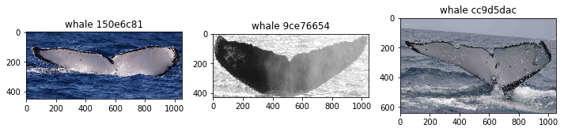

```python
# visualize some images: check color schema and varying size in pixels
# e.g. compare n_image=65, n_image=24 and n_image = 23
plt.figure(figsize=[12,7])

plt.subplot(131)
raw_image = mpimg.imread(train_images[853])
plt.imshow(raw_image)
plt.title("whale "+train_images[853][-12:-4])

plt.subplot(132)
raw_image = mpimg.imread(train_images[6015])
plt.imshow(raw_image)
plt.title("whale "+train_images[6015][-12:-4])

plt.subplot(133)
raw_image = mpimg.imread(train_images[7888])
plt.imshow(raw_image)
plt.title("whale "+train_images[7888][-12:-4])
plt.show()
```

```python
# check what fraction of images are grayscale (copied from another Notebook)
def is_gray_scale(img_path):
    # https://stackoverflow.com/questions/23660929/how-to-check-whether-a-jpeg-image-is-color-or-gray-scale-using-only-python-stdli
    im = Image.open(img_path).convert('RGB')
    w,h = im.size
    for i in range(w):
        for j in range(h):
            r,g,b = im.getpixel((i,j))
            if r != g != b: return False
    return True
```

```python
# we verify within a 1% subset
#shuffled_portion = random.sample(train_images,len(train_images))[:int(0.01*len(train_images))]
#is_gray = [is_gray_scale(i) for i in shuffled_portion]
```

```python
#n_gray = is_gray.count(True) / len(is_gray)
#print("Pecentage of gray images:", n_gray)
```

```
Text(0.5,1,'color whale')
```

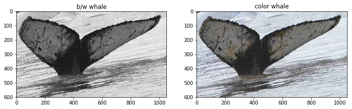

```python
# as an example:
n = 18
img = io.imread(train_images[n], as_gray=True)
img_rgb = io.imread(train_images[n])
# change shape into (1,m,n)
#img = np.expand_dims(img, axis=0)
plt.figure(figsize=[12,7])
plt.subplot(121)
plt.imshow(img,cmap = 'gray')
plt.title("b/w whale")
plt.subplot(122)
plt.imshow(img_rgb)
plt.title("color whale")
```

### Mask

```
Text(0.5,1,'bright fluke - Sobel')
```

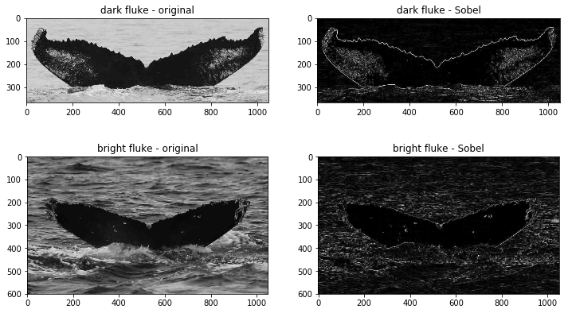

```python
# we apply a sobel mask as suggested by michele
img = io.imread(train_images[25], as_gray=True)
img_sobel = sobel(img[:,:])
img2 = io.imread(train_images[56], as_gray=True)
img2_sobel = sobel(img2[:,:])

plt.figure(figsize=[12,7])
plt.subplot(221)
plt.imshow(img[:,:],cmap = 'gray')
plt.title("dark fluke - original")
plt.subplot(222)
plt.imshow(img_sobel,cmap = 'gray')
plt.title("dark fluke - Sobel")
plt.subplot(223)
plt.imshow(img2[:,:],cmap = 'gray')
plt.title("bright fluke - original")
plt.subplot(224)
plt.imshow(img2_sobel,cmap = 'gray')
plt.title("bright fluke - Sobel")
```

Comment: this looks like a promising approach. For both brighter and darker-than-backgound flukes we obtain a similar silhouette and small features such as spots are preserved. A drawback is that flukes seen from the front (typicall darker) will not distinguishible from flukes seen from the back (typically brighter).

Notes: we need to find out how to get rid of text.

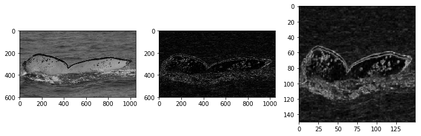

```python
img = io.imread('data/train/f009c06d.jpg', as_gray=True)
img = io.imread(train_images[259], as_gray=True)

plt.figure(figsize=[12,7])
plt.subplot(131)
plt.imshow(img,cmap = 'gray')
img = sobel(img)
plt.subplot(132)
plt.imshow(img,cmap = 'gray')
img = resize(img,(150,150),mode = 'constant', anti_aliasing=True)
plt.subplot(133)
plt.imshow(img,cmap = 'gray')
img = img.astype("uint8")
#name = img_path.split(".")[-2].split("/")[-1]
#imageio.imwrite(path_preprocessed + name + ".jpg", img)
```

```
Text(0.5,1,'location:18')
```

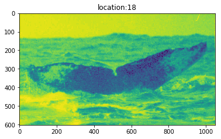

```python
img = io.imread('data/train/f009c06d.jpg', as_gray=True)
plt.imshow(img)
plt.title("location:" + str(n))
```

### Apply grayscaling + Sobel filter + resize and save to background

```
(327, 1050)
(150, 150)
```

```
Text(0.5,1,'whale - upscaled')
```

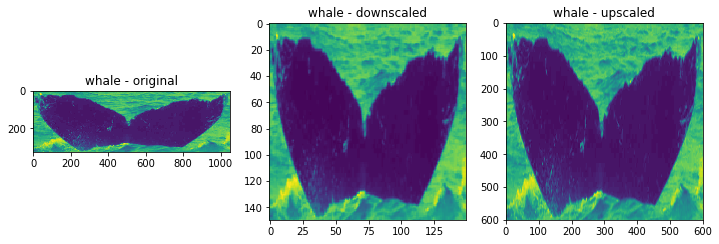

```python
# resize options

img1 = io.imread(train_images[21], as_gray=True)
print(img1.shape)
# adjust width and height to your needs
width = 150
height = 150
# use one of these filter options to resize the image
img2 = resize(img1,(width,height),mode = 'reflect', anti_aliasing=True)
print(img2.shape)
img3 = resize(img1,(4*width,4*height),mode = 'reflect', anti_aliasing=True)

plt.figure(figsize=[12,7])
plt.subplot(131)
plt.imshow(img1)
plt.title("whale - original")
plt.subplot(132)
plt.imshow(img2)
plt.title("whale - downscaled")
plt.subplot(133)
plt.imshow(img3)
plt.title("whale - upscaled")
```

Comment: with rescaling we give up on some important information such as whale size and proportions. There is large room for improvement here. We chose to downsize most of whales for computation reasons. We might increase pixel count later on.

```python
# create new folder
path_preprocessed = "data/train_preprocessed/"
if not os.path.exists(path_preprocessed):
    os.makedirs(path_preprocessed)
```

```python
pixel_width = 225

def preprocess_whale(img_path, save=True, w=pixel_width):

    img = io.imread(img_path, as_gray=True)
    maximum = np.amax(img)
    if maximum <= 1.0:
        img = img*255
    img = sobel(img)
    img = resize(img, (w, w),mode = 'reflect', anti_aliasing=True)
    maximum = np.amax(img)
    if maximum <= 1.0:
        img = img*255
    img = img.astype("uint8")

    if save == True:
        name = img_path.split(".")[-2].split("/")[-1]
        imageio.imwrite(path_preprocessed + name + ".jpg", img)
        #scipy.misc.imsave(path_gray_sodel + name + ".png",  img, format=None)

    return None
```

```python
now = time.time()
for item in train_images:
    preprocess_whale(item)
print("Time taken: {} s".format(int((time.time()-now))))
```

```
Time taken: 584 s
```

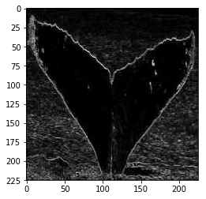

```python
# check
check_img = io.imread("data/train_preprocessed/8224f7c6.jpg", as_gray=True)
plt.imshow(check_img,cmap = 'gray')
```

Note: the dowscaled b/w folder is 91 MB. The original color folder was 284 MB.

### Augment

Note: given that CNN are invariant under isometries we decide for now to apply random shear and zoom augmentation only.

```
(1, 1, 150, 150)
```

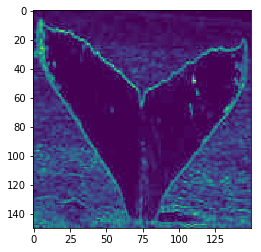

```python
datagen = ImageDataGenerator(
        #rescale=1./255,
        #we change non-isometrical parameters: zoom and shear
        shear_range=0.1,
        zoom_range=0.1,
        horizontal_flip=False,
        #rotation_range=5,
        fill_mode='constant',
        zca_whitening=False,
        data_format="channels_first")

#zoom_range=0.0,
#width_shift_range=0.0
#height_shift_range=0.2
#rotation_range=10
#featurewise_center=True,
#featurewise_std_normalization=True

img = io.imread("data/train_preprocessed/8224f7c6.jpg", as_gray=True)
plt.imshow(img)
img_s = img.reshape((1,) + img.shape)  # this is a Numpy array with shape (1, 1, 150, 150)
img_s = img_s.reshape((1,) + img_s.shape)
#img_s = np.transpose(img_s)
#img_s=np.swapaxes(img_s,0,2)
#img_s = img_s[:150,:150,:,:]
print(img_s.shape)
```

```
(1, 1, 150, 150)
```

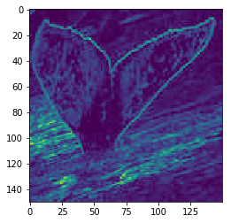

```python
img = io.imread("data/train_preprocessed/0078af23.jpg", as_gray=True)
plt.imshow(img)
img_p = img.reshape((1,) + img.shape)  # this is a Numpy array with shape (1, 1, 150, 150)
img_p = img_p.reshape((1,) + img_p.shape)
#img_s = np.transpose(img_s)
#img_s=np.swapaxes(img_s,0,2)
#img_s = img_s[:150,:150,:,:]
print(img_p.shape)
```

```python
# create new folder
path_practice = "data/practice/"
if not os.path.exists(path_practice):
    os.makedirs(path_practice)
```

```python
k = np.concatenate((img_s, img_p), axis=0)
```

```python
k.shape[0]
```

```
2
```

```python
#data = img_s
data = np.concatenate((img_s, img_p), axis=0)
batch_size = len(k)
max_images = 6
i=0

# https://keras.io/preprocessing/image/
for batch in datagen.flow(data, batch_size=data.shape[0], shuffle=True, save_format='jpg'):
    for j in range(batch.shape[0]):
        if i >= max_images:
            sys.exit()
        img = batch[j,0,:,:]
        img = img.astype("uint8")
        imageio.imwrite(path_practice + "_" +  str(i) +  ".jpg", img)
        i+=1
```

```
An exception has occurred, use %tb to see the full traceback.

SystemExit
```

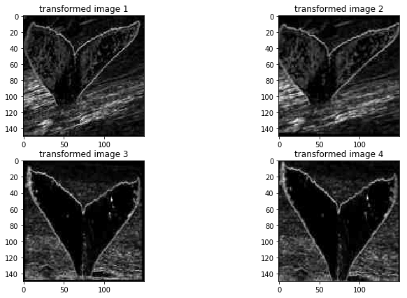

```python
transformed_images = glob("data/practice/*jpg")
images = [io.imread(k, as_gray=True) for k in transformed_images]
random.shuffle(images)
images = images[:4]

plt.figure(figsize=[12,7])
for i in range(len(images)):
    n = 221+i
    plt.subplot(n)
    plt.imshow(images[i],cmap = 'gray')
    plt.title("transformed image " + str(i+1))
```